# COVID-19 Data Report

Jack Cook

2023-05-08

## 1. Summary

The purpose of this report is to provide an update for the New Jersey Public Health Department on various county-level COVID-19 data across the United States. This report shows visualized distributions of data related to the following:

- COVID-19 Deaths and Cases per 100K people
- Rates of Mask Usage
- Overall Vaccination Rates

#### Central Findings

- **COVID-19 Deaths:** Overall, the average COVID-19 deaths per 100K people is about 436 deaths. The bottom 25% of U.S. counties have less than 320.6 deaths per 100K people, while the top 25% of counties have a death rate of over 540.1 per 100K people.
- **COVID-19 Cases:** The average COVID-19 cases per 100K people is about 30,950. The bottom 25% of U.S. counties have a case count of less than 26,562.9 per 100K people, while the top 25% of counties have a case count of more than 34,681.3 per 100K people.
- **Mask Usage:** The top five counties with residents who indicated they ‘always’ wear a mask include Inyo, CA, Yates, NY, Mono, CA, Hudspeth, TX, and El Paso, TX. The bottom 5 counties are all in Montana, including, Valley, Daniels, McCone, Roosevelt, and Phillips counties.
- **Vaccination Rates:** On average, 54.1% of people have completed their COVID-19 vaccinations, however, the distribution of completed vaccinations varies widely across counties. In terms of the CDC social vulnerability index, those counties in Group A have the highest vaccination rates in terms of overall distribution, while Group D has the lowest. Read on to view the highest and lowest vaccination rates by county in the U.S.

## 2. Data and Methodology

The data used in this analysis is sourced from two different datasets:

[**1. CDC COVID-19 Vaccinations in the United States, County**](https://data.cdc.gov/Vaccinations/COVID-19-Vaccinations-in-the-United-States-County/8xkx-amqh/data)

- This dataset is a collection and aggregation of vaccination data compiled from the CDC’s official healthcare partners. This report specifically focuses on COVID-19 cases and deaths per 100K people at the county-state level. The data in this report is from March 23, 2023.

[**2. The New York Times Mask Usage Survey by County**](https://github.com/nytimes/covid-19-data)

- This dataset was sourced from a NY Times national survey of 250K respondents conducted between July 2 and July 14 2020. It includes respondents’ answer to the following question: “How often do you wear a mask in public when you expect to be within six feet of another person?” For the purposes of this report we looked at the distribution of responses of those who replied “Always.”

## 3. COVID-19 Deaths and Cases to Date

#### Distribution of COVID-19 Deaths per 100K People

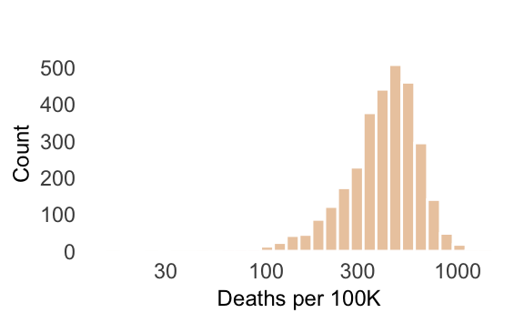

#### Distribution of COVID-19 Cases per 100K People

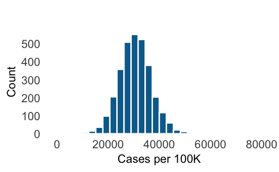

## 4. Estimated Rates of Mask Usage

#### Distribution of People Who Indicated They ‘Always’ Wear a Mask

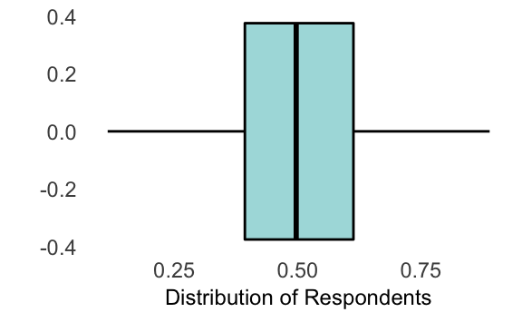

Counties with Highest Mask Usage

| county | state | ALWAYS |
| --- | --- | --- |
| Inyo | California | 0.9 |
| Yates | New York | 0.9 |
| Mono | California | 0.9 |
| Hudspeth | Texas | 0.9 |
| El Paso | Texas | 0.9 |

Counties with Lowest Mask Usage

| county | state | ALWAYS |
| --- | --- | --- |
| Valley | Montana | 0.1 |
| Daniels | Montana | 0.1 |
| McCone | Montana | 0.1 |
| Roosevelt | Montana | 0.1 |
| Phillips | Montana | 0.1 |

## 5. Rates of Vaccination

#### Distribution of COVID-19 Vaccination Rates

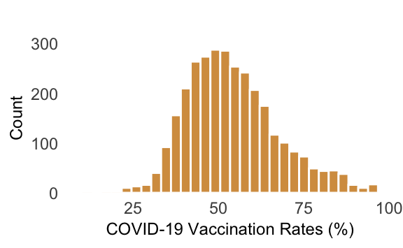

#### Vaccination Rate Distribution by Social Vulnerability Index

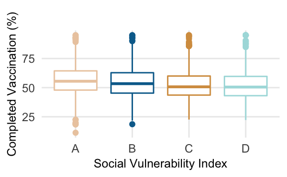

#### Highest and Lowest Vaccination Rates by County

Counties with Highest Vaccination Rates

| county | state | vaxComplete |
| --- | --- | --- |
| Apache | Arizona | 95 |
| Santa Cruz | Arizona | 95 |
| Imperial | California | 95 |
| San Juan | Colorado | 95 |
| Chattahoochee | Georgia | 95 |
| Geary | Kansas | 95 |
| McKinley | New Mexico | 95 |
| Culebra | Puerto Rico | 95 |
| Lares | Puerto Rico | 95 |
| Brooks | Texas | 95 |
| Irion | Texas | 95 |
| Maverick | Texas | 95 |
| Presidio | Texas | 95 |
| Starr | Texas | 95 |
| Webb | Texas | 95 |
| Teton | Wyoming | 95 |

Counties with Lowest Vaccination Rates

| county | state | vaxComplete |
| --- | --- | --- |
| Slope | North Dakota | 11.3 |
| Cameron | Louisiana | 18.4 |
| McCone | Montana | 18.5 |
| Holmes | Ohio | 18.6 |
| Loving | Texas | 18.9 |